# Reproducible Research Course Project 1 - Activity Monitoring Data

## Part 1: Code for reading in the dataset and/or processing the data

```r
setwd('C:/Users/mtsc7/Desktop/coursera')
activity <- read.csv("activity.csv")
summary(activity)
```

```
##      steps                date          interval
##  Min.   :  0.00   2012-10-01:  288   Min.   :   0.0
##  1st Qu.:  0.00   2012-10-02:  288   1st Qu.: 588.8
##  Median :  0.00   2012-10-03:  288   Median :1177.5
##  Mean   : 37.38   2012-10-04:  288   Mean   :1177.5
##  3rd Qu.: 12.00   2012-10-05:  288   3rd Qu.:1766.2
##  Max.   :806.00   2012-10-06:  288   Max.   :2355.0
##  NA's   :2304     (Other)   :15840
```

```r
str(activity)
```

```
## 'data.frame':    17568 obs. of  3 variables:
##  $ steps   : int  NA NA NA NA NA NA NA NA NA NA ...
##  $ date    : Factor w/ 61 levels "2012-10-01","2012-10-02",..: 1 1 1 1 1 1 1 1 1 1 ...
##  $ interval: int  0 5 10 15 20 25 30 35 40 45 ...
```

## Part 2: Histogram of the total number of steps taken each day

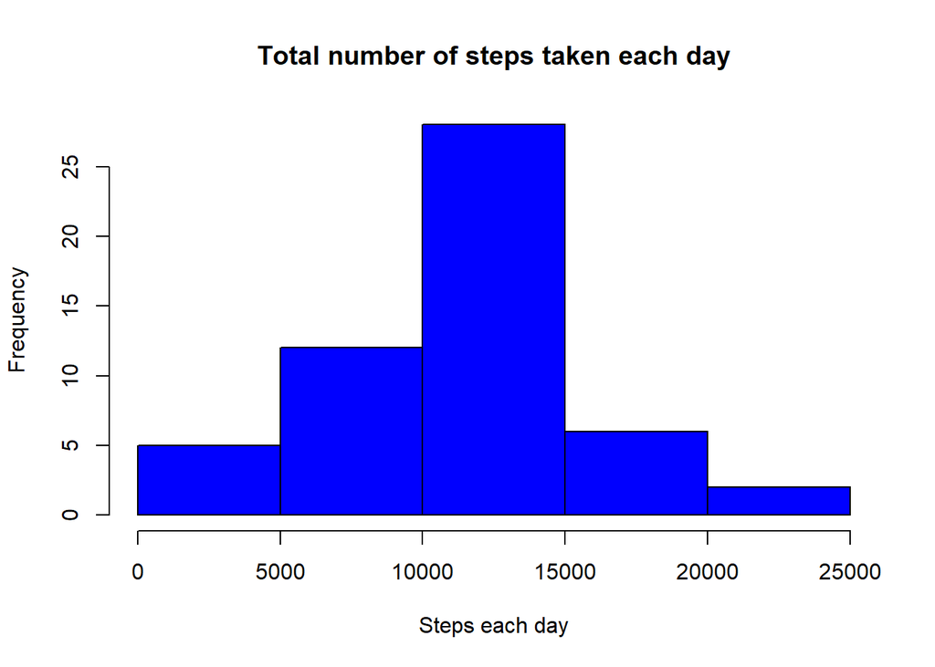

```r
steps_day <- aggregate(steps ~ date, data = activity, FUN = sum, na.rm = TRUE)
hist(steps_day$steps, xlab = "Steps each day", main = "Total number of steps taken each day", col = "blue")
```

## Part 3: Mean and median number of steps taken each day

```r
mean_steps <- mean(steps_day$steps)
mean_steps <- round(mean_steps, digits = 1)
print(mean_steps)
```

```
## [1] 10766.2
```

```r
median_steps <- median(steps_day$steps)
median_steps <- round(median_steps, digits = 1)
print(median_steps)
```

```
## [1] 10765
```

## Part 4: Time series plot of the average number of steps taken

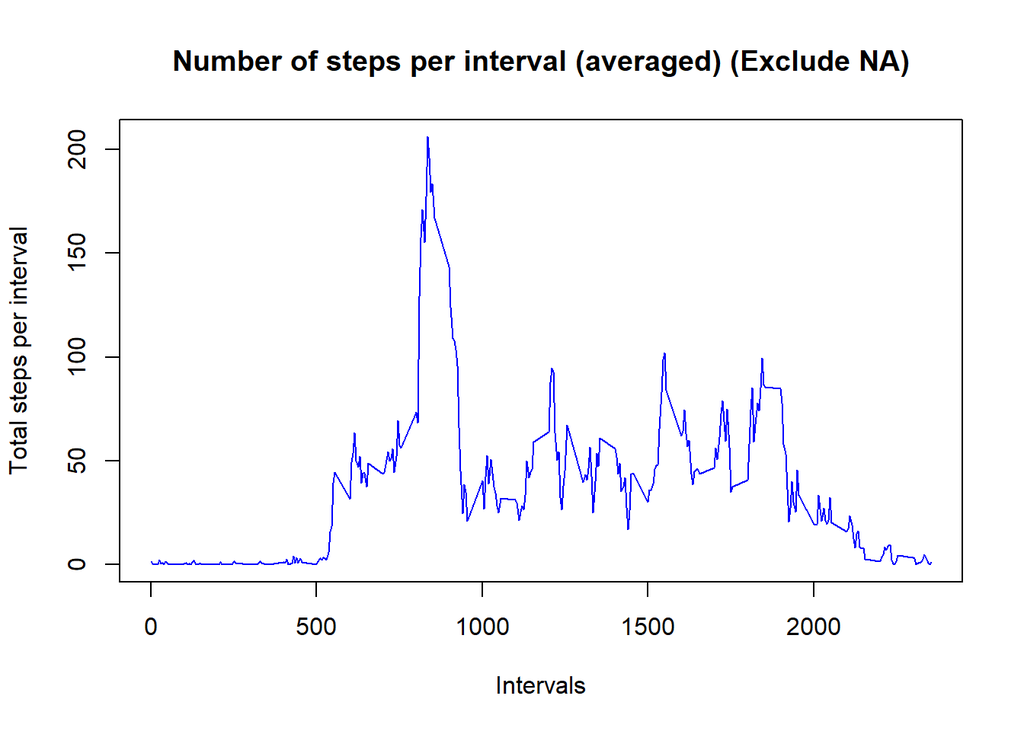

```r
mean_steps_ts <- aggregate(steps ~ interval, data = activity, FUN = mean, na.rm = TRUE)
plot(mean_steps_ts$interval, mean_steps_ts$steps, type = "l", col = "blue", xlab = "Intervals", ylab = "Total steps per interval", main = "Number of steps per interval (averaged) (Exclude NA)")
```

## Part 5: The 5-minute interval that, on average, contains the maximum number of steps

```r
max_steps <-max(mean_steps_ts$steps)
max_steps_interval <- mean_steps_ts$interval[which(mean_steps_ts$steps == max_steps)]
print(max_steps_interval)
```

```
## [1] 835
```

```r
max_steps <- round(max_steps, digits = 1)
print(max_steps)
```

```
## [1] 206.2
```

ANSWER: The maximum steps taken is 206.2 and occurred at interval 835.

## Part 6: Code to describe and show a strategy for imputing missing data

### STRATEGY - The missing data will be imputed with the mean number of steps across all days with non-NA data for that particular interval.

```r
total_na <- sum(is.na(activity))

Steps_Interval <- tapply(activity$steps, activity$interval, mean, na.rm = TRUE)
activity_split <- split(activity, activity$interval)

#Impute missing data for each interval
for(i in 1:length(activity_split)){
  activity_split[[i]]$steps[is.na(activity_split[[i]]$steps)] <- Steps_Interval[i]
}
activity_imputed <- do.call("rbind", activity_split)
activity_imputed <- activity_imputed[order(activity_imputed$date) ,]
```

ANSWER: The total number of missing value is 2304.

## Part 7: Histogram of the total number of steps taken each day after missing values are imputed

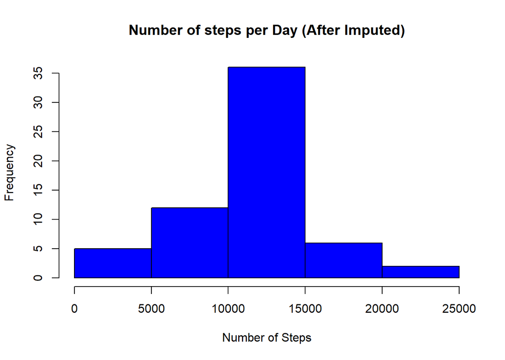

```r
steps_imputed <- tapply(activity_imputed$steps, activity_imputed$date, sum)
hist(steps_imputed, xlab = "Number of Steps", main = "Number of steps per Day (After Imputed)", col = "blue")
```

```r
#Mean and median number of steps taken each day
imputed_mean_steps <- mean(steps_imputed)
imputed_mean_steps <- round(imputed_mean_steps, digits = 1)

imputed_median_steps <- median(steps_imputed)
imputed_median_steps <- round(imputed_median_steps, digits = 1)

#Compare the results in a dataframe
compare_mean_median <- data.frame(c(mean_steps, median_steps), c(imputed_mean_steps, imputed_median_steps))
colnames(compare_mean_median) <- c("Before Impute NA", "After impute NA")
rownames(compare_mean_median) <- c("mean", "median")

library(xtable)
xt <- xtable(compare_mean_median)
print(xt, type  = "html")
```

[output not shown]

## Step 8: Panel plot comparing the average number of steps taken per 5-minute interval across weekdays and weekends

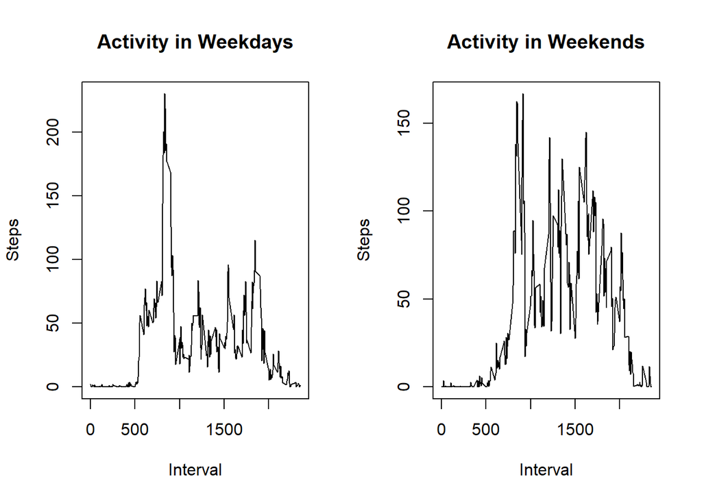

```r
activity_imputed$wktype <- ifelse(weekdays(as.Date(activity_imputed$date)) == "Saturday" | weekdays(as.Date(activity_imputed$date)) == "Sunday", "weekend", "weekday")

#Average steps per interval for weekdays and weekends
steps_weekday <- tapply(activity_imputed[activity_imputed$wktype == "weekday" ,]$steps, activity_imputed[activity_imputed$wktype == "weekday" ,]$interval, mean, na.rm = TRUE)
steps_weekend <- tapply(activity_imputed[activity_imputed$wktype == "weekend" ,]$steps, activity_imputed[activity_imputed$wktype == "weekend" ,]$interval, mean, na.rm = TRUE)

#Create a 2 panel plot for weekday and weekend
par(mfrow=c(1,2))

plot(as.numeric(names(steps_weekday)),
     steps_weekday,
     xlab = "Interval",
     ylab = "Steps",
     main = "Activity in Weekdays",
     type = "l")

plot(as.numeric(names(steps_weekend)),
     steps_weekend,
     xlab = "Interval",
     ylab = "Steps",
     main = "Activity in Weekends",
     type = "l")
```

#### ANSWER: Activity (by number of steps) have started earlier in the weekdays and lasted over a shorter duration (by the occurance of high peaks). However activity on weekends started slightly later and spread over longer duration.